# set_9_VEC

Set data directory path

Install and load required packages

```r
chooseCRANmirror(graphics=FALSE, ind=33)
if (!require("urca")) install.packages("urca")
if (!require("tsDyn")) install.packages("tsDyn")
library(aTSA)
library(xts)
library(anytime)
library(urca)
library(tsDyn)
```

Dowload data on quarterly Personal Consumption Expenditure Source: https://fred.stlouisfed.org/series/PCEC, download file PCEC.csv

Dowload data on quarterly GDP Source: https://fred.stlouisfed.org/series/GDP, download file GDP.csv

Load, log, convert to xts format, and merge data on quarterly Personal Consumption Expenditure and GDP

```r
setwd("C:/Teaching/Undergrad/data ECO374")
data_PCEC <- read.csv(file="PCEC.csv", header=TRUE, sep=",")
data_GDP <- read.csv(file="GDP.csv", header=TRUE, sep=",")
data_PCEC$PCEC <- log(data_PCEC$PCEC)
data_GDP$GDP <- log(data_GDP$GDP)
xtsdata_PCEC <- xts(x=data_PCEC[c("PCEC")], order.by=anytime(data_PCEC$DATE))
xtsdata_GDP <- xts(x=data_GDP[c("GDP")], order.by=anytime(data_GDP$DATE))
xtsdata <- merge.xts(xtsdata_PCEC,xtsdata_GDP)
```

Data time series plot

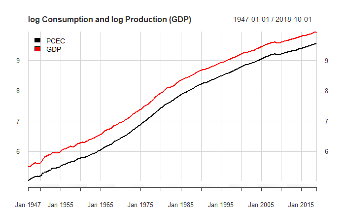

```r
plot.xts(xtsdata, plot.type = c("single"), main ="log Consumption and log Production (GDP)" , legend.loc = "topleft", grid.col="lightgray")
```

Plot of log Consumption vs log Production (GDP)

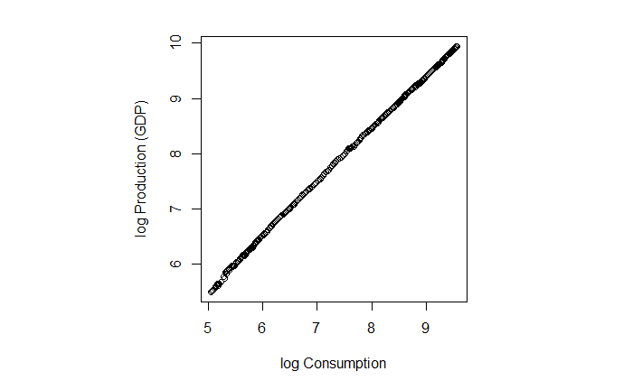

```r
par(pty="s")
plot(x=data_PCEC$PCEC, y=data_GDP$GDP, xlab=("log Consumption"), ylab=("log Production (GDP)"))
```

Unit root test for log GDP

```r
adf.test(xtsdata$GDP)
```

```
Augmented Dickey-Fuller Test
alternative: stationary

Type 1: no drift no trend
     lag   ADF p.value
[1,]   0 21.41    0.99
[2,]   1  6.93    0.99
[3,]   2  5.12    0.99
[4,]   3  5.42    0.99
[5,]   4  5.02    0.99
[6,]   5  5.03    0.99
Type 2: with drift no trend
     lag   ADF p.value
[1,]   0 -3.75   0.010
[2,]   1 -2.31   0.208
[3,]   2 -1.98   0.334
[4,]   3 -1.96   0.343
[5,]   4 -2.05   0.309
[6,]   5 -2.24   0.233
Type 3: with drift and trend
     lag  ADF p.value
[1,]   0 2.96    0.99
[2,]   1 1.53    0.99
[3,]   2 1.16    0.99
[4,]   3 1.53    0.99
[5,]   4 1.62    0.99
[6,]   5 1.91    0.99
----
Note: in fact, p.value = 0.01 means p.value <= 0.01
```

Unit root test for log Consumption

```r
adf.test(xtsdata$PCEC)
```

```
Augmented Dickey-Fuller Test
alternative: stationary

Type 1: no drift no trend
     lag   ADF p.value
[1,]   0 24.25    0.99
[2,]   1  9.54    0.99
[3,]   2  4.89    0.99
[4,]   3  4.14    0.99
[5,]   4  4.21    0.99
[6,]   5  3.45    0.99
Type 2: with drift no trend
     lag   ADF p.value
[1,]   0 -3.34  0.0153
[2,]   1 -2.63  0.0907
[3,]   2 -1.66  0.4612
[4,]   3 -1.47  0.5329
[5,]   4 -1.65  0.4633
[6,]   5 -1.43  0.5445
Type 3: with drift and trend
     lag  ADF p.value
[1,]   0 3.24    0.99
[2,]   1 2.69    0.99
[3,]   2 1.50    0.99
[4,]   3 1.30    0.99
[5,]   4 1.56    0.99
[6,]   5 1.26    0.99
----
Note: in fact, p.value = 0.01 means p.value <= 0.01
```

Run Johansen Cointegration Test The output does not provide p-values, therefore the value of the test statistic “test” needs to be compared for each hypothesized values of r with the critical values at 10pct, 5pct, and 1pct to determine the outcome of the test.

Here, for r = 0, “test” > (10pct or 5pct or 1pct) and hence we reject the null of no cointegration. We conclude that log Production (GDP) and log Consumption (PCEC) are cointegrated.

```r
Y <- as.matrix(as.data.frame(xtsdata))
jotest <- ca.jo(Y)
summary(jotest)
```

```
######################
# Johansen-Procedure #
######################

Test type: maximal eigenvalue statistic (lambda max) , with linear trend

Eigenvalues (lambda):
[1] 0.15575239 0.01839592

Values of teststatistic and critical values of test:

          test 10pct  5pct  1pct
r <= 1 |  5.31  6.50  8.18 11.65
r = 0  | 48.42 12.91 14.90 19.19

Eigenvectors, normalised to first column:
(These are the cointegration relations)

          PCEC.l2    GDP.l2
PCEC.l2  1.000000  1.000000
GDP.l2  -1.023743 -1.210719

Weights W:
(This is the loading matrix)

             PCEC.l2      GDP.l2
PCEC.d -0.0911978766 0.003195957
GDP.d  -0.0003948533 0.004976386
```

Plot of deviations from equilibrium

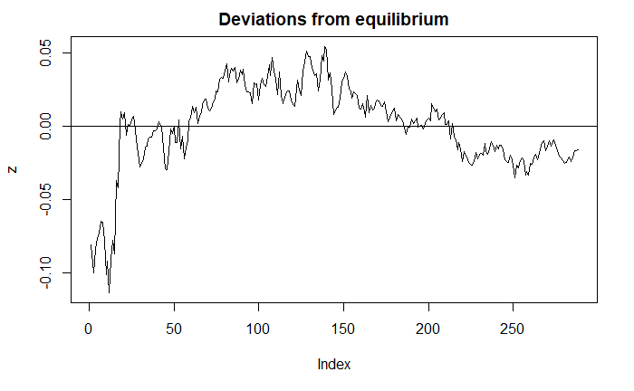

```r
reg <- lm(data_GDP$GDP ~ data_PCEC$PCEC)
z <- residuals(reg)
plot(z, main ="Deviations from equilibrium", type="l")
abline(h=0)
```

Estimate VEC model with one lag

```r
vecm <- lineVar(data=Y, model = c("VECM"), r=1, lag=1)
summary(vecm)
```

```
#############
###Model VECM
#############
Full sample size: 288   End sample size: 286
Number of variables: 2  Number of estimated slope parameters 8
AIC -5550.376   BIC -5517.472   SSR 0.04557005
Cointegrating vector (estimated by 2OLS):
   PCEC       GDP
r1    1 -0.944822

              ECT                Intercept         PCEC -1             GDP -1
Equation PCEC -0.0146(0.0045)**  0.0116(0.0010)*** -0.1088(0.0758)     0.3522(0.0672)***
Equation GDP  -0.0104(0.0048)*   0.0063(0.0011)*** 0.2911(0.0802)***   0.2840(0.0711)***
```

```r
AIC(vecm)
```

```
[1] -5550.376
```

Choose lag order based on AIC minimization

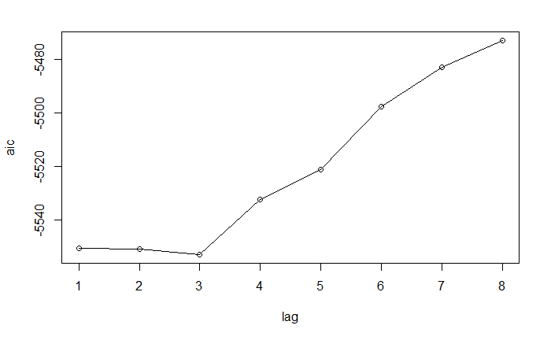

```r
maxlag=8
lag <- seq(0,0,length.out=maxlag)
aic <- seq(0,0,length.out=maxlag)
for (k in 1:maxlag) {
  vecm <- lineVar(data=Y, model = c("VECM"), r=1, lag=k)
  lag[k] <- k
  aic[k] <- AIC(vecm)
}
plot(lag,aic)
lines(lag,aic)
```

Forecast

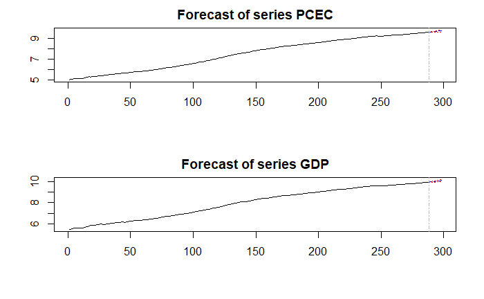